# 白葡萄酒质量分析

## 多因素分析

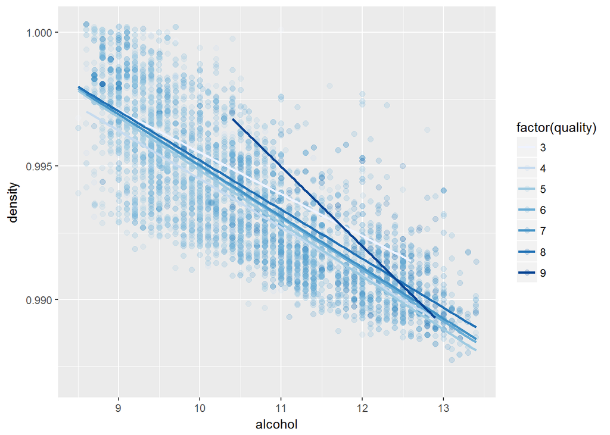

质量、密度和酒精度这三个变量上，趋势清晰。 即质量更好的白葡萄酒倾向于密度更低，酒精度数越高。

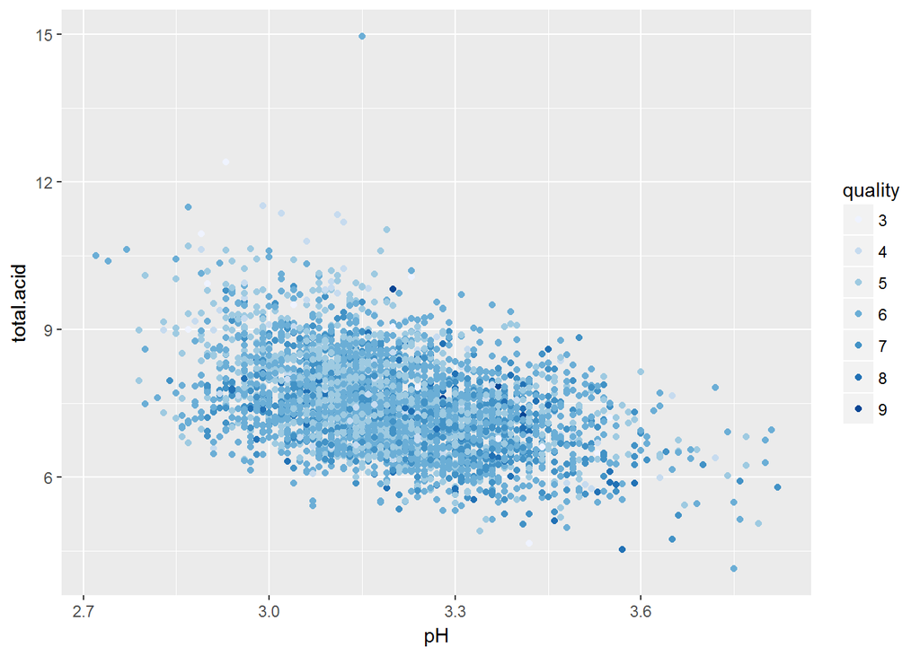

质量、pH和总体酸度上，趋势并不完全清晰，但存在着可观测的数据。 即质量好的白葡萄酒酸度不高，且一般不会超过9g/dm3。

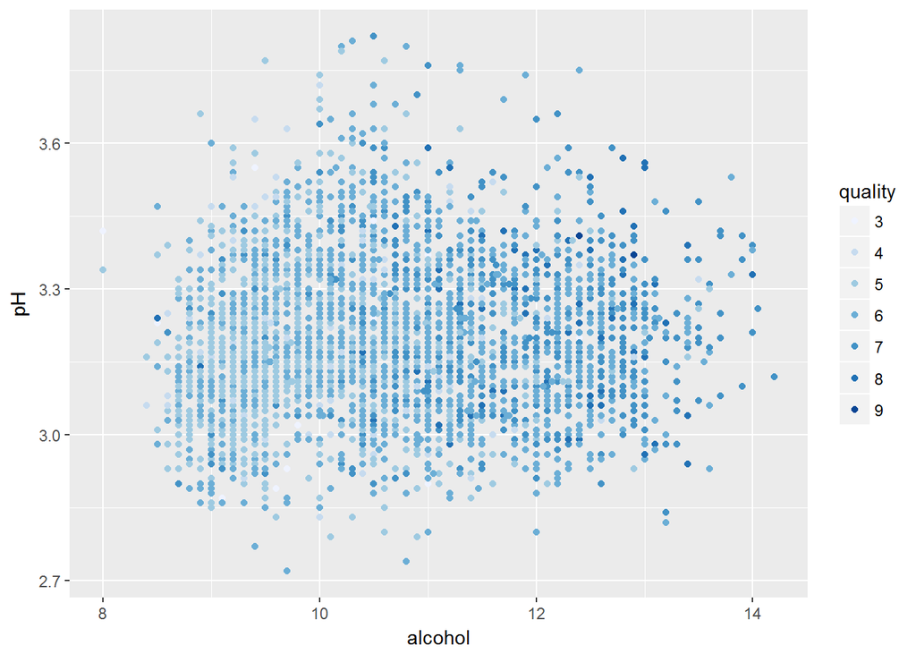

质量、pH和酒精度上，趋势主要由酒精度主导，pH值对质量评价影响不大。

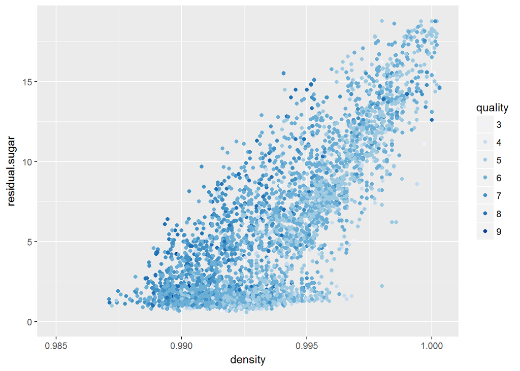

质量、密度和残糖上，引导质量的趋势主要由密度主导，残糖对质量影响较小。

## 多因素分析

### 谈谈在这部分调查中看到的一些关系。

相比较于pH和酸度，密度和酒精度这两个变量在影响质量评价上，趋势清晰。即质量更好的白葡萄酒倾向于密度更低，酒精度数越高。

### 特征之间有什么有趣的交互？

密度越大，酒精度数越低，残糖量越高。

## 最终视图和总结

### 图一

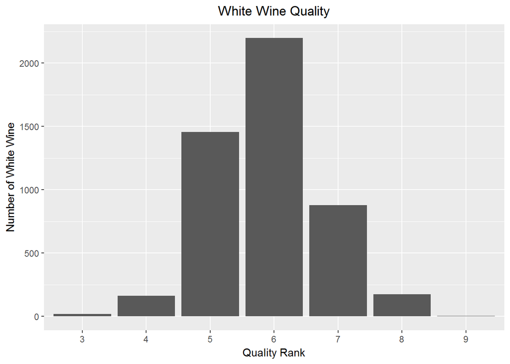

### 说明一

观察质量评分的结果分布，图形呈现单峰型,评分6呈现最大值即出现了2198次。高评分与低评分均出现较少（每个专家将葡萄酒的品质分为0（非常差）和10（非常优秀））。

### 图二

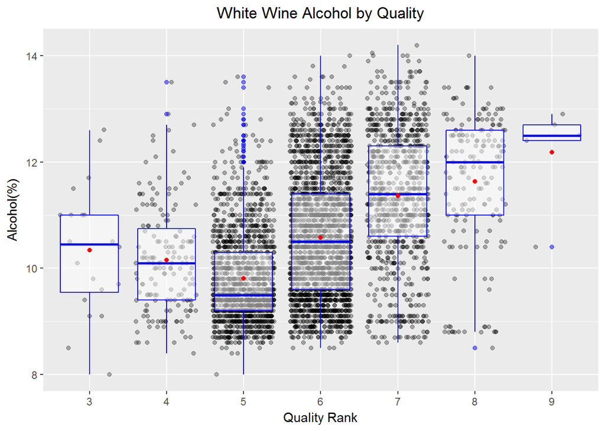

### 图三

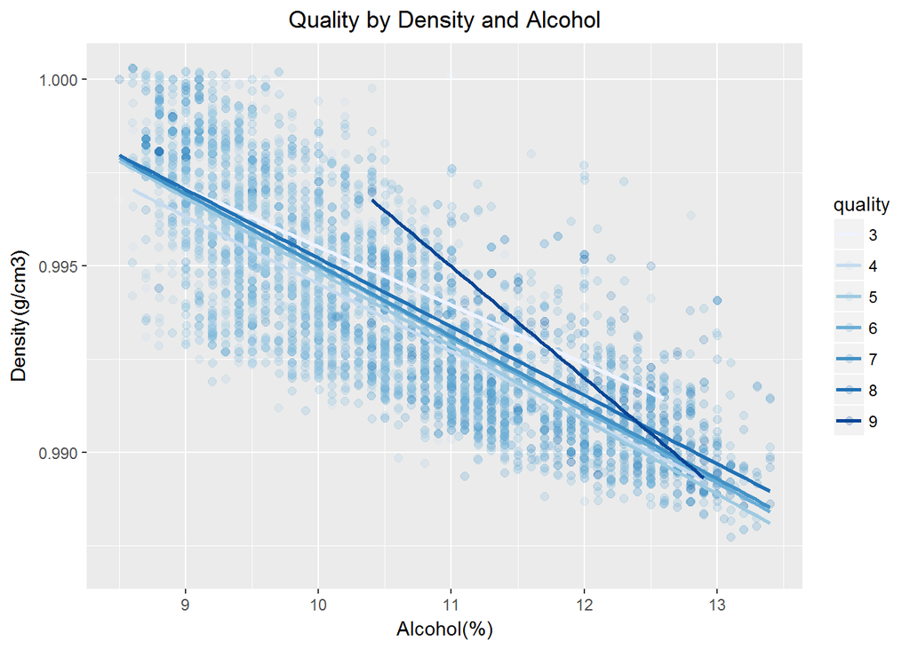

### 说明三

质量、密度和酒精度这三个变量上，趋势清晰。即质量评价越好的白葡萄酒倾向于密度更低，酒精度数越高。

## 反思

该白葡萄酒数据集包含了4898种白葡萄酒，1列索引值，11个量化每种酒化学成分的输入变量，以及一个基于感官数据的输出变量（质量评分）。 我从理解数据集中的各个变量开始，然后我持续对变量间的关系进行了观察。

在对质量评价影响较小的变量（氯化物、游离二氧化硫、二氧化硫总量、硫酸盐）排出后，发现酒精和密度对质量评价的影响最大，而酸度（对固定酸度、挥发性酸度、柠檬酸三者做了处理，即求和生成新变量总体酸度）、pH值与质量评价并没有呈现强烈的相关关系。并且酒精与酸碱指标（酸度、pH）也并不存在明显的相关性。 最后总结出了一个重要结论是质量评价得分越高的白葡萄酒倾向于密度更低，酒精度越高。

该数据集缺少了一些离散化的数据，例如产地、生产年份或储藏时长。这些变量都将有可能影响我目前研究发现的核心变量：密度和酒精度数。未来有可能，我将获取这些数据后，进一步完善对白葡萄酒质量评价的影响因素分析。